# Overdose Deaths EDA - Week 3 by Kyle Maher

### Packages

```r
library(tidyverse)
library(this.path)
library(readxl)
library(gt)
library(maps)
library(patchwork)
library(lubridate)
library(usmap)
library(scales)
set.seed(28)
```

# Setup

### Overdose Data

- Remove columns with a constant value
  - “Period”
  - “Percent Complete”
- Coalesce “Predicted Value” and “Data Value”
- Rename to snake_case format

```r
raw_overdose <- read_csv(
  file.path(
    dirname(this.path()),
    "..",
    "data",
    "VSRR_Provisional_Drug_Overdose_Death_Counts.csv"
  )
)

overdose <- raw_overdose %>%
  mutate(value = coalesce(`Predicted Value`, `Data Value`)) %>%
  select(
    -Period,
    -"Percent Complete",
    -Footnote,
    -"Footnote Symbol",
    -"Predicted Value",
    -"Data Value"
  ) %>%
  rename(
    state = "State Name",
    state_abbreviation = State,
    year = Year,
    month = Month,
    indicator = Indicator,
    percent_pending_investigation = "Percent Pending Investigation"
  ) %>%
  mutate(
    month_year = my(paste(month, year)),
    state = as.factor(state),
    state_abbreviation = as.factor(state_abbreviation),
    year = as.integer(year),
    month = factor(month, levels = month.name, ordered = TRUE),
    indicator = as.factor(indicator),
    value = as.numeric(value),
    percent_pending_investigation = as.numeric(percent_pending_investigation)
  )
```

### Population Data

- Drop April 2021 estimates column
- Use pivot_longer() to transform the year into one column
- Remove the period before the state names

```r
raw_pop <- read_excel(
  file.path(
    dirname(this.path()),
    "..",
    "data",
    "NST-EST2024-POP.xlsx"
  ),
  range = "A4:G62"
)

# Drop estimates, pivot year columns together, remove regions, remove period.
pop <- raw_pop %>%
  rename(state = "...1", base_estimates_april_2021 = "...2") %>%
  select(-base_estimates_april_2021) %>%
  pivot_longer(
    cols = `2020`:`2024`,
    names_to = "year",
    values_to = "population"
  ) %>%
  mutate(state = sub("^\\.", "", state)) %>%
  mutate(year = as.integer(year))
```

### State Data (For Region)

- From the built in state.name and state.region
- Add the states that appear in the Population Data

```r
state <- data.frame(
  state = state.name,
  state_region = state.region
)

# Add states that appear in pop
odd_states <- data.frame(
  state =
    c("New York City",
      "District of Columbia",
      "Puerto Rico",
      "United States"),
  state_region =
    c("Northeast",
      "Northeast",
      NA,
      NA)
)

state <- bind_rows(state, odd_states)

state <- state %>%
  mutate(
    state = as.factor(state),
    state_region = as.factor(state_region)
  )
```

### State Area

```r
state_area <- read_csv(
  file.path(
    dirname(this.path()),
    "..",
    "data",
    "StateArea.csv"
  )
) %>%
  select("State and other areas2", "Land Area1") %>%
  rename(
    state = "State and other areas2",
    square_miles = "Land Area1"
  ) %>%
  slice(-(1:4)) %>%
  filter(!is.na(state)) %>%
  mutate(state = str_remove_all(state, "[0-9]")) %>%
  mutate(square_miles = str_remove_all(square_miles, ",")) %>%
  mutate(
    state = as.factor(state),
    square_miles = as.numeric(square_miles)
  )
```

### State Unemployment Rate

```r
state_unemployment <- read_csv(
  file.path(
    dirname(this.path()),
    "..",
    "data",
    "StateUnemploymentRate.csv"
  )
) %>%
  select(-Rank) %>%
  rename(
    state = "State",
    unemployment_rate = "August 2025(p)"
  ) %>%
  slice(-1) %>% # Remove Subheader row
  mutate(
    state = as.factor(state),
    unemployment_rate = as.numeric(unemployment_rate)
  )
```

### Literacy Rates

```r
state_literacy <- read_csv(
  file.path(
    dirname(this.path()),
    "..",
    "data",
    "us.-literacy-rates-by-state-2025.csv" # released 2025
  )
) %>%
  rename(
    state = state,
    literacy_score = "LiteracyRatesAverageLiteracyScore_2024"
  ) %>%
  select(state, literacy_score) %>%
  mutate(
    state = as.factor(state),
    literacy_score = as.numeric(literacy_score)
  )
```

### Join Dataframes

```r
df <- overdose %>%
  left_join(pop, by = c("state", "year")) %>%
  left_join(state, by = "state") %>%
  left_join(state_area, by = "state") %>%
  left_join(state_unemployment, by = "state") %>%
  left_join(state_literacy, by = "state") %>%
  mutate(state_lower = tolower(state))
```

# Investigate Limits

### Questions the Data Can Not Answer

- Is there Seasonality?
  - The rolling sum removes any seasonality.
- Which drug is most likely to overdose on?
  - No data on the number of users.
  - No data on doseage amounts.

### Questions the Data Can Answer

- Do states with a highter population density also have more overdoses?
- Do states with a highter unemployment rate also have more overdoes?
- Do states with a lower literacy rate also have more overdoeses?

However, checking these questions will not explain any causation, only correlation.

# Setup for Correlations

### Isolate Yearly Sum for 2024

Select the values for december of 2024, which are the sum from January through December for 2024.

```r
df <- df %>%
  filter(month_year == "2024-12-01", !is.na(value)) %>%
  filter(
    state != "United States",
    state != "Puerto Rico",
    state != "New York City"
  )
```

### Filtered Dataframe:

```r
df %>%
  select(
    state,
    population,
    square_miles,
    unemployment_rate,
    literacy_score,
    indicator,
    value
  ) %>%
  sample_n(10) %>%
  gt()
```

| state | population | square_miles | unemployment_rate | literacy_score | indicator | value |
| --- | --- | --- | --- | --- | --- | --- |
| New York | 19867248 | 47126 | 4.0 | 215 | Synthetic opioids, excl. methadone (T40.4) | 1592.00000 |
| Virginia | 8811195 | 39490 | 3.6 | 214 | Natural, semi-synthetic, & synthetic opioids, incl. methadone (T40.2-T40.4) | 1167.00000 |
| Massachusetts | 7136171 | 7800 | 4.8 | 225 | Natural & semi-synthetic opioids, incl. methadone (T40.2, T40.3) | 246.00000 |
| Iowa | 3241488 | 55857 | 3.8 | 215 | Percent with drugs specified | 97.65808 |
| Mississippi | 2943045 | 46923 | 3.9 | 219 | Percent with drugs specified | 98.16701 |
| Tennessee | 7227750 | 41235 | 3.6 | 215 | Number of Drug Overdose Deaths | 2580.00000 |
| New Hampshire | 1409032 | 8953 | 3.0 | 221 | Natural & semi-synthetic opioids (T40.2) | 17.00000 |
| Kansas | 2970606 | 81759 | 3.8 | 213 | Percent with drugs specified | 97.85714 |
| Oklahoma | 4095393 | 68595 | 3.1 | 207 | Number of Deaths | 43868.00000 |
| Oklahoma | 4095393 | 68595 | 3.1 | 207 | Natural & semi-synthetic opioids, incl. methadone (T40.2, T40.3) | 97.00000 |

### Control for Population

- Use deaths per 100,000 people

```r
df <- df %>%
  mutate(value = (value / population) * 100000)
```

### Calculate State Population Density

- Population per square mile

```r
df <- df %>%
  mutate(population_density = (population / square_miles))
```

# Calculate Pearson Correlations

### Population Density

```r
df %>%
  group_by(indicator) %>%
  summarise(
    correlation = cor(
      value,
      population_density,
      method = "pearson",
      use = "complete.obs"
    ),
    n = n(),
    .groups = "drop"
  ) %>%
  arrange(desc(correlation)) %>%
  gt() %>%
  data_color(
    columns = 2,
    fn = scales::col_numeric(
      palette = c("#F9F3EF", "#D2C1B6"),
      domain = NULL
    )
  ) %>%
  tab_options(table.align = "left") %>%
  tab_header(title = "Population Density vs Deaths by Indicator")
```

Population Density vs Deaths by Indicator

| indicator | correlation | n |
| --- | --- | --- |
| Cocaine (T40.5) | 0.7579466 | 43 |
| Heroin (T40.1) | 0.6208286 | 32 |
| Synthetic opioids, excl. methadone (T40.4) | 0.5091737 | 46 |
| Opioids (T40.0-T40.4,T40.6) | 0.4871526 | 46 |
| Natural, semi-synthetic, & synthetic opioids, incl. methadone (T40.2-T40.4) | 0.4848308 | 46 |
| Number of Drug Overdose Deaths | 0.4536324 | 51 |
| Percent with drugs specified | 0.3078242 | 51 |
| Methadone (T40.3) | 0.2409807 | 39 |
| Natural & semi-synthetic opioids, incl. methadone (T40.2, T40.3) | 0.2089910 | 46 |
| Natural & semi-synthetic opioids (T40.2) | 0.1249137 | 46 |
| Number of Deaths | -0.1082636 | 51 |
| Psychostimulants with abuse potential (T43.6) | -0.1411146 | 46 |

### Unemployment Rate

```r
df %>%
  group_by(indicator) %>%
  summarise(
    correlation = cor(
      value,
      unemployment_rate,
      method = "pearson",
      use = "complete.obs"
    ),
    n = n(),
    .groups = "drop"
  ) %>%
  arrange(desc(correlation)) %>%
  gt() %>%
  data_color(
    columns = 2,
    fn = scales::col_numeric(
      palette = c("#F9F3EF", "#D2C1B6"),
      domain = NULL
    )
  ) %>%
  tab_options(table.align = "left") %>%
  tab_header(title = "Unemployment Rate vs Deaths by Indicator")
```

Unemployment Rate vs Deaths by Indicator

| indicator | correlation | n |
| --- | --- | --- |
| Number of Drug Overdose Deaths | 0.52269072 | 51 |
| Synthetic opioids, excl. methadone (T40.4) | 0.46793104 | 46 |
| Opioids (T40.0-T40.4,T40.6) | 0.46552280 | 46 |
| Natural, semi-synthetic, & synthetic opioids, incl. methadone (T40.2-T40.4) | 0.46040699 | 46 |
| Cocaine (T40.5) | 0.31071170 | 43 |
| Natural & semi-synthetic opioids, incl. methadone (T40.2, T40.3) | 0.23034091 | 46 |
| Psychostimulants with abuse potential (T43.6) | 0.22928495 | 46 |
| Heroin (T40.1) | 0.21864091 | 32 |
| Natural & semi-synthetic opioids (T40.2) | 0.17923547 | 46 |
| Methadone (T40.3) | 0.05544705 | 39 |
| Number of Deaths | -0.15268119 | 51 |
| Percent with drugs specified | -0.25925612 | 51 |

### Literacy Score

```r
df %>%
  group_by(indicator) %>%
  summarise(
    correlation = cor(
      value,
      literacy_score,
      method = "pearson",
      use = "complete.obs"
    ),
    n = n(),
    .groups = "drop"
  ) %>%
  arrange(correlation) %>%
  gt() %>%
  data_color(
    columns = 2,
    fn = scales::col_numeric(
      palette = c("#F9F3EF", "#D2C1B6"),
      domain = NULL
    )
  ) %>%
  tab_options(table.align = "left") %>%
  tab_header(title = "Literacy Scores vs Deaths by Indicator")
```

Literacy Scores vs Deaths by Indicator

| indicator | correlation | n |
| --- | --- | --- |
| Psychostimulants with abuse potential (T43.6) | -0.51197965 | 46 |
| Number of Drug Overdose Deaths | -0.40957898 | 51 |
| Synthetic opioids, excl. methadone (T40.4) | -0.37975579 | 46 |
| Opioids (T40.0-T40.4,T40.6) | -0.37900809 | 46 |
| Natural, semi-synthetic, & synthetic opioids, incl. methadone (T40.2-T40.4) | -0.37829075 | 46 |
| Heroin (T40.1) | -0.25049273 | 32 |
| Natural & semi-synthetic opioids, incl. methadone (T40.2, T40.3) | -0.22084387 | 46 |
| Methadone (T40.3) | -0.20607948 | 39 |
| Number of Deaths | -0.20167907 | 51 |
| Percent with drugs specified | -0.13474388 | 51 |
| Natural & semi-synthetic opioids (T40.2) | -0.11372786 | 46 |
| Cocaine (T40.5) | -0.03772933 | 43 |

# Major Correlations

Population Density vs Deaths by Indicator

| indicator | correlation | n |
| --- | --- | --- |
| Cocaine (T40.5) | 0.7579466 | 43 |
| Heroin (T40.1) | 0.6208286 | 32 |
| Synthetic opioids, excl. methadone (T40.4) | 0.5091737 | 46 |
| Opioids (T40.0-T40.4,T40.6) | 0.4871526 | 46 |
| Natural, semi-synthetic, & synthetic opioids, incl. methadone (T40.2-T40.4) | 0.4848308 | 46 |
| Number of Drug Overdose Deaths | 0.4536324 | 51 |

Unemployment Rate vs Deaths by Indicator

| indicator | correlation | n |
| --- | --- | --- |
| Number of Drug Overdose Deaths | 0.5226907 | 51 |
| Synthetic opioids, excl. methadone (T40.4) | 0.4679310 | 46 |
| Opioids (T40.0-T40.4,T40.6) | 0.4655228 | 46 |
| Natural, semi-synthetic, & synthetic opioids, incl. methadone (T40.2-T40.4) | 0.4604070 | 46 |
| Cocaine (T40.5) | 0.3107117 | 43 |

Literacy Scores vs Deaths by Indicator

| indicator | correlation | n |
| --- | --- | --- |
| Psychostimulants with abuse potential (T43.6) | -0.5119796 | 46 |
| Number of Drug Overdose Deaths | -0.4095790 | 51 |
| Synthetic opioids, excl. methadone (T40.4) | -0.3797558 | 46 |
| Opioids (T40.0-T40.4,T40.6) | -0.3790081 | 46 |
| Natural, semi-synthetic, & synthetic opioids, incl. methadone (T40.2-T40.4) | -0.3782907 | 46 |

### Population Density

- Cocaine (T40.5)
  - 0.7579

### Unemployment Rate

- Number of Drug Overdose Deaths
  - 0.5227

### Literacy Scores

- Psychostimulants with abuse potential (T43.6)
  - -0.5120

# Common Correlations

### All Three:

- Natural, semi-synthetic, & synthetic opioids, incl. methadone (T40.2-T40.4)
- Synthetic opiods, excl. methadone (T40.4)

### Population Density:

- Cocaine (T40.5)

### Unemployment Rate

- Cocaine (T40.5)

# Population Density vs Cocaine Overdose Deaths

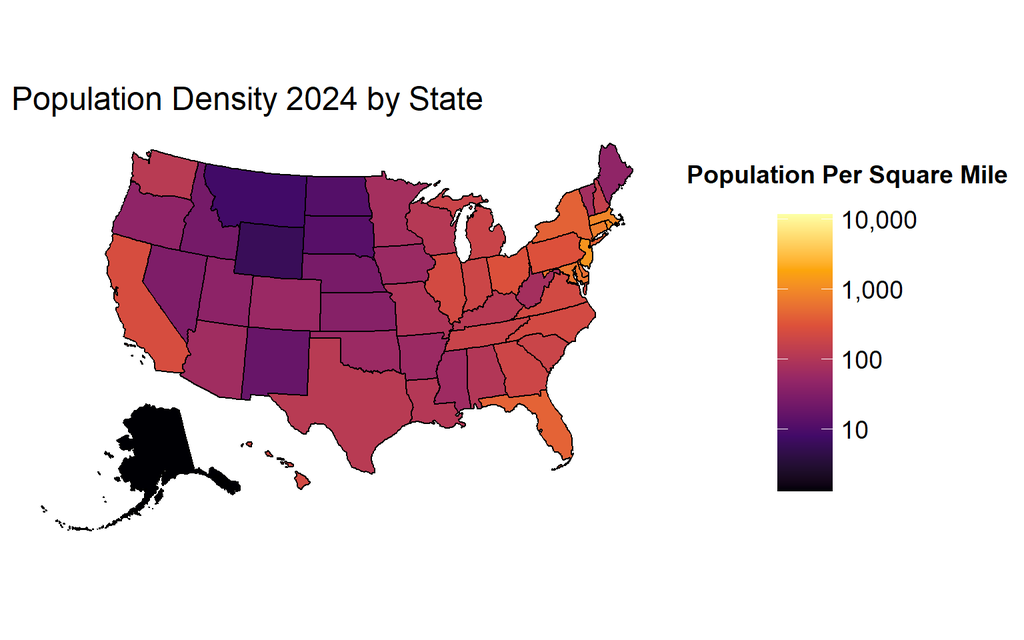

```r
population_density <- plot_usmap(
  data = df,
  values = "population_density",
  regions = "states"
) +
  scale_fill_viridis_c(
    option = "inferno",
    trans = "log",
    breaks = trans_breaks("log10", function(x) 10^x),
    labels = comma_format()
  ) +
  labs(
    title = "Population Density 2024 by State",
    fill = "Population Per Square Mile"
  ) +
  theme(
    legend.position = "right",
    plot.title = element_text(size = 18),
    legend.key.size = unit(1.1, "cm"),
    legend.title = element_text(
      size = 14,
      face = "bold",
      vjust = 5,
      hjust = .5
    ),
    legend.text = element_text(size = 14)
  )

cocaine_deaths <- plot_usmap(
  data = filter(df, indicator == "Cocaine (T40.5)"),
  values = "value",
  regions = "states"
) +
  scale_fill_viridis_c(
    option = "inferno",
    trans = "log",
    breaks = trans_breaks("log10", function(x) 10^x),
    labels = comma_format()
  ) +
  labs(
    title = "Number of Cocaine Overdose Deaths in 2024 by State",
    fill = "Count Per 100,000 People"
  ) +
  theme(
    legend.position = "right",
    plot.title = element_text(size = 18),
    legend.key.size = unit(1.1, "cm"),
    legend.title = element_text(
      size = 14,
      face = "bold",
      vjust = 5,
      hjust = .5
    ),
    legend.text = element_text(size = 14)
  )

population_density
```

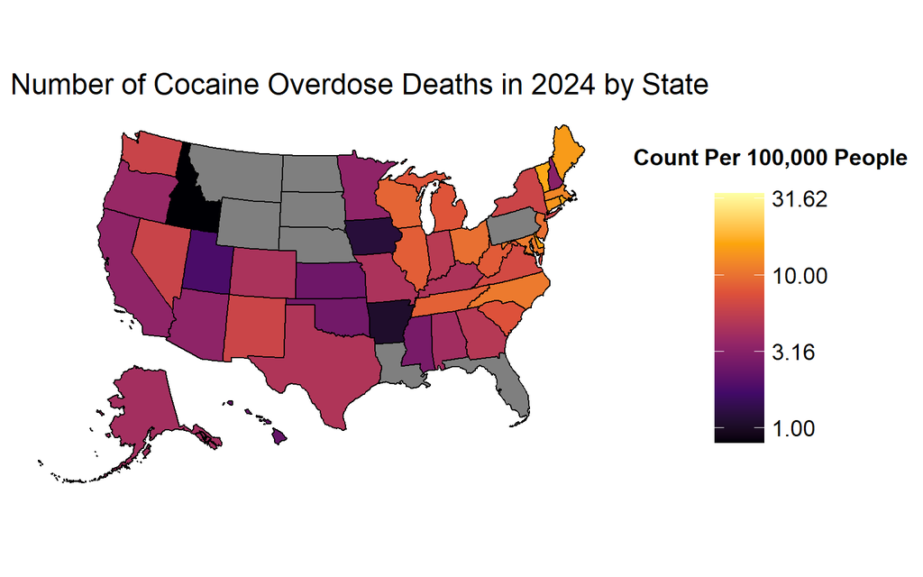

```r
cocaine_deaths
```

East Coast and District of Columbia match this correlation well.

# Unemployment Rate vs Number of Drug Overdose Deaths

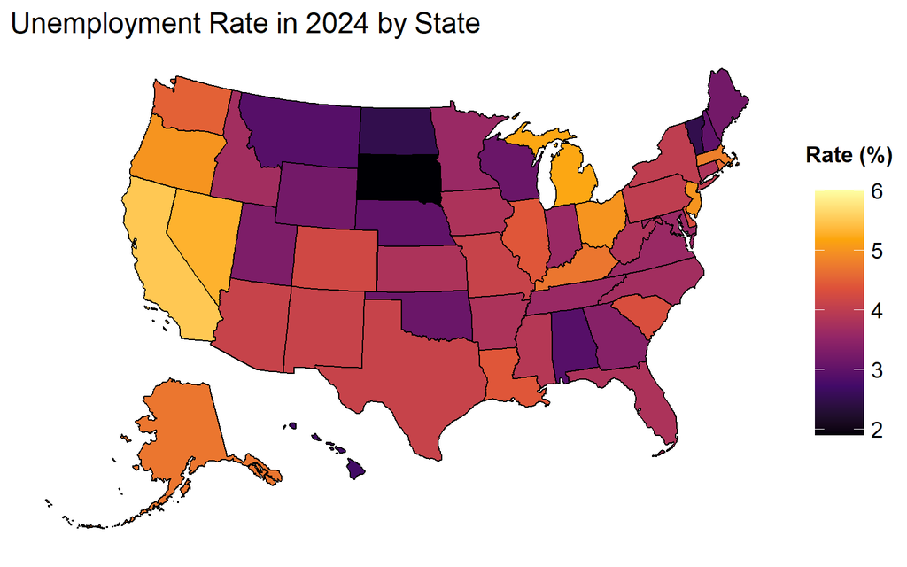

```r
unemployment_rate <- plot_usmap(
  data = df,
  values = "unemployment_rate",
  regions = "states"
) +
  scale_fill_viridis_c(option = "inferno") +
  labs(
    title = "Unemployment Rate in 2024 by State",
    fill = "Rate (%)"
  ) +
  theme(
    legend.position = "right",
    plot.title = element_text(size = 18),
    legend.key.size = unit(1.1, "cm"),
    legend.title = element_text(
      size = 14,
      face = "bold",
      vjust = 5,
      hjust = .5
    ),
    legend.text = element_text(size = 14)
  )

overdose_deaths <- plot_usmap(
  data = filter(df, indicator == "Number of Drug Overdose Deaths"),
  values = "value",
  regions = "states"
) +
  scale_fill_viridis_c(option = "inferno") +
  labs(
    title = "Number of Drug Overdose Deaths in 2024 by State",
    fill = "Count Per 100,000 People"
  ) +
  theme(
    legend.position = "right",
    plot.title = element_text(size = 18),
    legend.key.size = unit(1.1, "cm"),
    legend.title = element_text(
      size = 14,
      face = "bold",
      vjust = 5,
      hjust = .5
    ),
    legend.text = element_text(size = 14)
  )

unemployment_rate
```

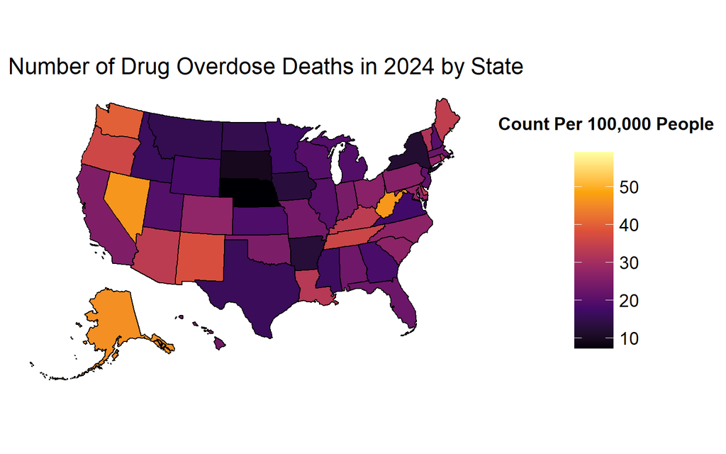

```r
overdose_deaths
```

Midwest and Southeast align well with the correlation.

# Literacy Scores vs Number of Psychostimulants Deaths

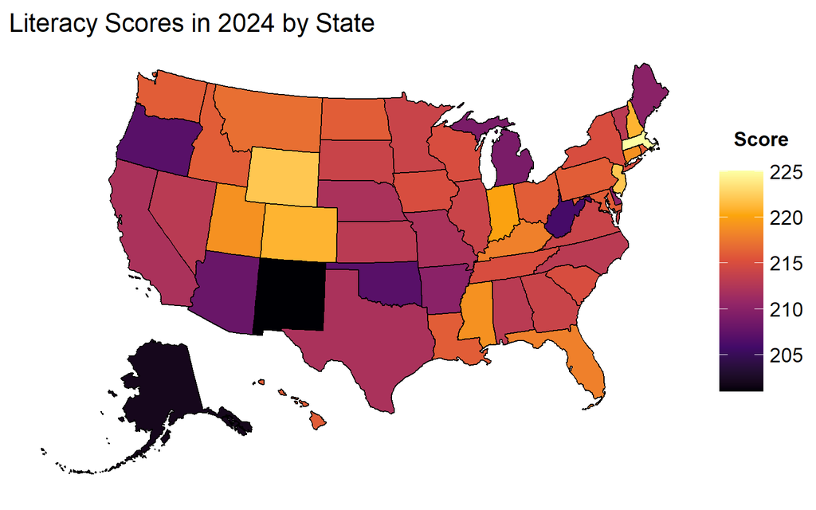

```r
literacy_scores <- plot_usmap(
  data = df,
  values = "literacy_score",
  regions = "states"
) +
  scale_fill_viridis_c(option = "inferno") +
  labs(
    title = "Literacy Scores in 2024 by State",
    fill = "Score"
  ) +
  theme(
    legend.position = "right",
    plot.title = element_text(size = 18),
    legend.key.size = unit(1.1, "cm"),
    legend.title = element_text(
      size = 14,
      face = "bold",
      vjust = 5,
      hjust = .5
    ),
    legend.text = element_text(size = 14)
  )

psychostimulant_deaths <- plot_usmap(
  data = filter(df, indicator == "Psychostimulants with abuse potential (T43.6)"),
  values = "value",
  regions = "states"
) +
  scale_fill_viridis_c(option = "inferno") +
  labs(
    title = "Number of Psychostimulant Overdose Deaths in 2024 by State",
    fill = "Count Per 100,000 People"
  ) +
  theme(
    legend.position = "right",
    plot.title = element_text(size = 18),
    legend.key.size = unit(1.1, "cm"),
    legend.title = element_text(
      size = 14,
      face = "bold",
      vjust = 5,
      hjust = .5
    ),
    legend.text = element_text(size = 14)
  )

literacy_scores
```

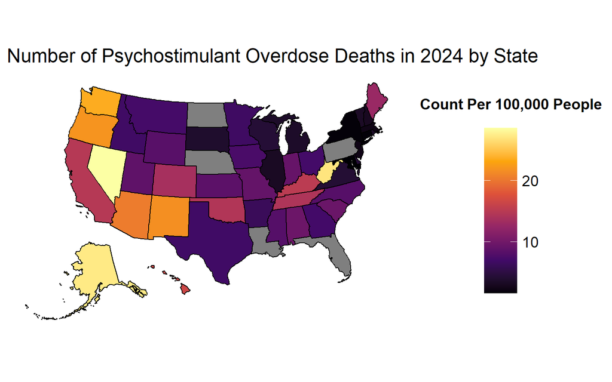

```r
psychostimulant_deaths
```

West Virginia and Alaska match the correlation very well.

# Conclusion

Most of the correlations appeared as expected with a postitive correlaiton between Population Density and Overdose Deaths, a positive correlation between state Unemployment Rate and Overdose Deaths, and a negative correlation betweeen state Literacy Score and Overdose Deaths.

The strongest corelation was between population density and overdose deaths due to Cocaine with a correlation of .758.

All three factors considered were correlated significantly with the folowing two indicators: - Natural, semi-synthetic, & synthetic opioids, incl. methadone (T40.2-T40.4) - Synthetic opiods, excl. methadone (T40.4)

# Data Sources

### Overdose Deaths

Ahmad FB, Cisewski JA, Rossen LM, Sutton P. Provisional drug overdose death counts. National Center for Health Statistics. 2025. DOI: https://dx.doi.org/10.15620/cdc/20250305008

### Populaiton

https://www.census.gov/data/tables/time-series/demo/popest/2020s-state-total.html

### State Area

https://www.census.gov/geographies/reference-files/2010/geo/state-area.html

### Unemployment Rate

https://www.bls.gov/web/laus/laumstrk.htm

### Literacy Score

https://worldpopulationreview.com/state-rankings/us-literacy-rates-by-state